# Simulation and Plotting

Pejman Mahboubi

7/30/2017

## Summary

This document is based on the book " Data Analysis Using Regression and Multilevel/Hierarchical Models" by Gelman and Hill, chapter 4.

## Data

We are using the kidiq.dta which is available in Gelman’s webpage http://www.stat.columbia.edu/~gelman/arm/software/. After downloading the zip file, go to “ARM_Data/child.iq/kidiq.dta”. To open the file, I installed package

```r
library(foreign)
df<-read.dta(file="~/Desktop/math/mixedmodel/ARM_Data/child.iq/kidiq.dta")
head(df)
```

```
##   kid_score mom_hs    mom_iq mom_work mom_age
## 1        65      1 121.11753        4      27
## 2        98      1  89.36188        4      25
## 3        85      1 115.44316        4      27
## 4        83      1  99.44964        3      25
## 5       115      1  92.74571        4      27
## 6        98      0 107.90184        1      18
```

## Bulding the model

Let’s use two predictors, mom.hs and mom.iq, to predict the kid.score. We also include the interaction term. We use different colors to indentify kids whose mom has high school diploma, versus others.

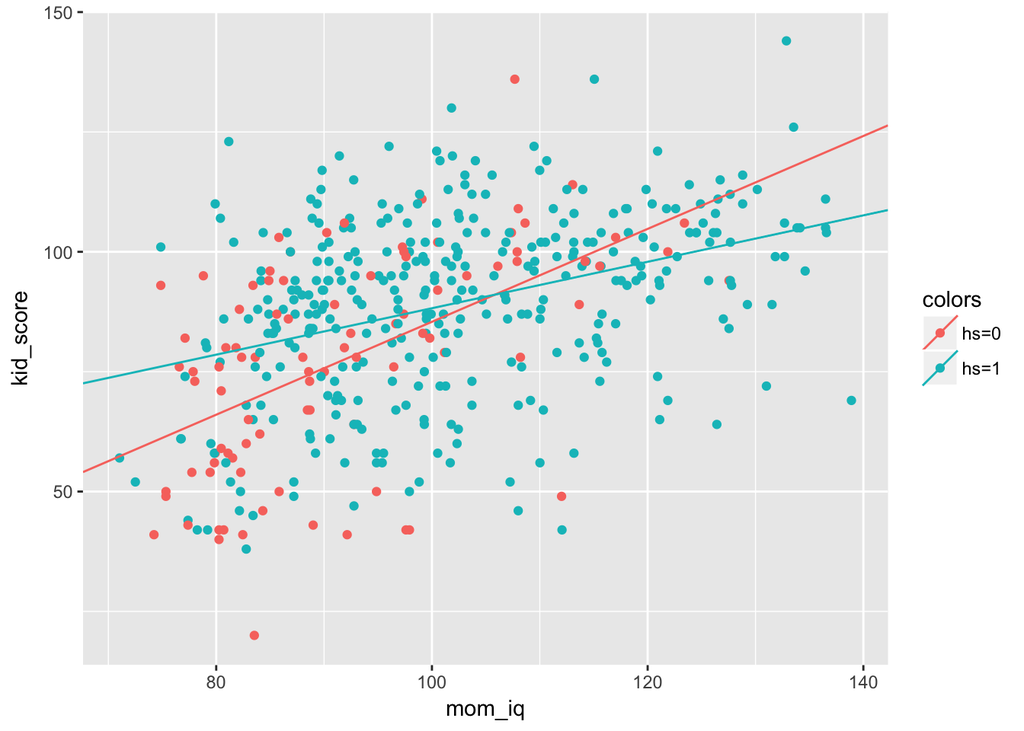

```r
library(ggplot2)
fit.3 <- lm (kid_score ~ mom_hs*mom_iq,df)
df$colors<-factor(ifelse(df$mom_hs==1,"red","blue"),label=c("hs=0","hs=1"))
d=data.frame(ic=c(coef(fit.3)[1],coef(fit.3)[1]+coef(fit.3)[2]),
             s=c(coef(fit.3)[3],coef(fit.3)[3]+coef(fit.3)[4]),
             colors = levels(df$colors),
             group=c("hs","No_hs"))
ggplot(data = df[,-c(4,5)],mapping = aes(x = mom_iq,y = kid_score,
                                         color = colors)) +
        geom_point()+
        geom_abline(data=d,mapping=aes(slope=s, intercept=ic,color=colors))
```

We can also visualize the confidence interval, using simulation as follows. The model coefficients are

```r
beta<-coef(fit.3)
print(beta)
```

```
##   (Intercept)        mom_hs        mom_iq mom_hs:mom_iq
##   -11.4820211    51.2682234     0.9688892    -0.4842747
```

Consider a student, say student1, whose mom has a high school diploma and has mom_iq$= 103.5$. To predict his or her score, we form a vector of predictors, call it predictor1, and do the following

```r
predictor1=c(1,1,103.5,103.5)
score=coef(fit.3)%*%predictor1
print(score)
```

```
##          [,1]
## [1,] 89.94381
```

Or we could simply use the predict function

```r
predict(object = fit.3,newdata  = data.frame(mom_hs=1,mom_iq=103.5,1))
```

```
##        1
## 89.94381
```

However, we cannot use the predict() function for the simulated coefficients. The covariance matrix below measures the uncertainty in coefficients beta.

```r
covvar <- vcov(fit.3)
print(covvar)
```

```
##               (Intercept)      mom_hs      mom_iq mom_hs:mom_iq
## (Intercept)    189.281841 -189.281841 -2.02209947    2.02209947
## mom_hs        -189.281841  235.241376  2.02209947   -2.46248198
## mom_iq          -2.022099    2.022099  0.02200586   -0.02200586
## mom_hs:mom_iq    2.022099   -2.462482 -0.02200586    0.02631437
```

Therefore, we can sample a set of 1000 coefficients by

```r
library(MASS)
beta.sim <- mvrnorm(1000, beta,covvar)
head(beta.sim)
```

```
##      (Intercept)   mom_hs    mom_iq mom_hs:mom_iq
## [1,]   -9.074411 50.46748 0.9673410    -0.5171952
## [2,]  -12.671320 47.41693 1.0208691    -0.4782517
## [3,]  -13.233084 48.74260 0.9912029    -0.4682264
## [4,]   -6.971622 53.62310 0.9139838    -0.5057550
## [5,]  -10.362036 54.34136 0.9595216    -0.5235142
## [6,]  -24.732177 62.72351 1.1271760    -0.6074626
```

beat.sim stores $1000$ sets of coefficients that are likely to be obtained from other samples (here df is a sample). We can compute the student1’s score for all these different coefficients by

```r
scores=beta.sim%*%predictor1
head(scores)
```

```
##          [,1]
## [1,] 87.98316
## [2,] 90.90651
## [3,] 89.63758
## [4,] 88.90316
## [5,] 89.10609
## [6,] 91.78167
```

If student2 has $predictor2=c(1,1,95,95)$ then to compute all 1000 predictions (corresponding to each set of coefficients) for both students we first form the matrix of predictors by

```r
predictor2=c(1,1,95,95)
predictors=matrix(c(predictor1,predictor2),nrow = 4,byrow = FALSE)
head(predictors)
```

```
##       [,1] [,2]
## [1,]   1.0    1
## [2,]   1.0    1
## [3,] 103.5   95
## [4,] 103.5   95
```

and then repeat the same matrix multiplication as above,

```r
scores<-beta.sim%*%predictors
head(scores)
```

```
##          [,1]     [,2]
## [1,] 87.98316 84.15692
## [2,] 90.90651 86.29426
## [3,] 89.63758 85.19228
## [4,] 88.90316 85.43322
## [5,] 89.10609 85.40003
## [6,] 91.78167 87.36411
```

The predict function, as mentioned above, does not allow us to work with simulated coefficients. However for the sake of completeness let me show you how to use it to predict the score for multiple students.

```r
predict(object = fit.3,newdata  = data.frame(mom_hs=c(1,1),mom_iq=c(103.5,95)))
```

```
##        1        2
## 89.94381 85.82458
```

Then we define the values at which the variables are held constant. This is because we cannot go beyond 2 dimensions. Therefore, by letting y axis to denote the kid’s score, we are confined to one predictor. Let’s set mom_hs to 1 and create values for mom_iq in a range suggested by the data

```r
hs1<-subset(df,df$mom_hs==1)
mn<-round(min(hs1$mom_iq))
mx<-round(max(hs1$mom_iq))
intrctn<-mom_iq<-seq(from = mn, to = mx,by = .1)
x <- cbind(1,1, mom_iq,intrctn)
head(x)
```

```
##          mom_iq intrctn
## [1,] 1 1   71.0    71.0
## [2,] 1 1   71.1    71.1
## [3,] 1 1   71.2    71.2
## [4,] 1 1   71.3    71.3
## [5,] 1 1   71.4    71.4
## [6,] 1 1   71.5    71.5
```

Next, for all range of $mom\_iq$ we compute kid_score, using all different coefficients. We denoted 7 different scores of 3 different students computed based on 7 different likely coefficints.

```r
SCORES<-x%*%t(beta.sim)
SCORES[c(1,300,600),(1:7)*100]
```

```
##           [,1]      [,2]      [,3]      [,4]      [,5]      [,6]     [,7]
## [1,]  74.76706  72.34123  75.97314  75.46457  70.91084  76.13579 77.89023
## [2,]  90.10723  87.82609  89.79671  87.97580  87.29113  89.26869 88.37921
## [3,] 105.49871 103.36273 103.66651 100.52887 103.72621 102.44550 98.90327
```

Next we plot the 1000 values of each iq, as a shaded area. To this end, we compute the maximum, minimum and the predicted value for each iq.

```r
df2<-data.frame(mom_iq=x[,3],
min=apply(X = SCORES,MARGIN = 1,min),
max=apply(X = SCORES,MARGIN = 1,max),
predicted=predict(object = fit.3,newdata = data.frame(mom_hs=1,mom_iq=x[,3]))
)
head(df2)
```

```
##   mom_iq      min      max predicted
## 1   71.0 67.33211 80.95028  74.19383
## 2   71.1 67.40028 80.98307  74.24230
## 3   71.2 67.46845 81.01586  74.29076
## 4   71.3 67.53661 81.04865  74.33922
## 5   71.4 67.60478 81.08143  74.38768
## 6   71.5 67.67295 81.11422  74.43614
```

Next, comes the plot

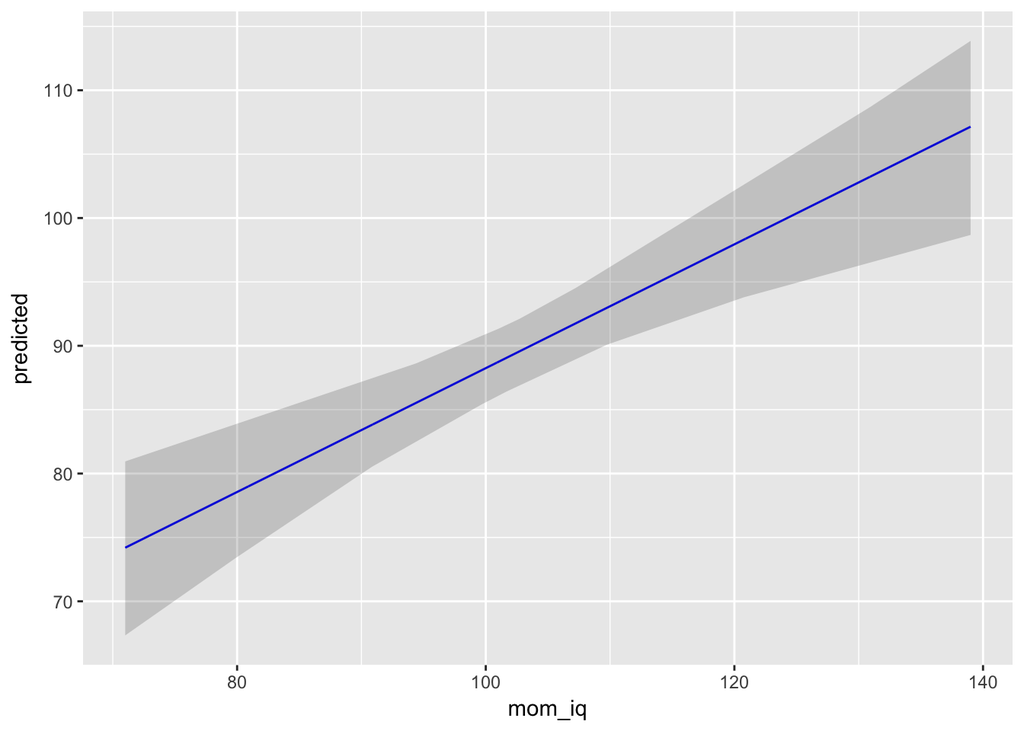

```r
ggplot(df2, aes(x=mom_iq)) +
  geom_line(aes(y=predicted), colour="blue") +
  geom_ribbon(aes(ymin=min, ymax=max), alpha=0.2)
```